# Bis620 - Final Project

### Author: Anjie Yao, Hang Li

## Background and Motvation

Urinary Tract Infections are common infections that happen when bacteria enter the urethra, and infect the urinary tract. UTIs can happen anywhere in the urinary system, including the kidneys, ureters, bladder, and urethra. UTIs are very common, especially in women. Women get UTIs up to 30 times more often than men do. Urine culture is a lab test for bacteria or germs in a urine sample. The results of urine culture usually take 1 to 3 days.

UTIs are common clinical conditions in emergency department (ED), with more than 3 million ED visits each year for UTIs, while it also has high diagnostic error rates (30-50%). Urine culture as the standard for UTIs diagnosis is usually not available because of the time it takes. Evaluations and treatment decision in a wide spectrum of patient populations and disease severity are needed to be conducted in ED, and UTIs are typically diagnosed using a combination of methods in ED, including a physical examination and a review of the patient’s symptoms.

Emergency physicians also face a different set of challenges than those by infectious disease specialists in a non-ED environment, and that diagnosis of UTI can often be difficult when mixed with a plethora of other conditions such as urolithiasis. With such complexity in ED-environment and noticeable insufficient diagnosis accuracy in ED, a decision support system based on machine learning algorithms that incorporate data such as patients’ demographics, vitals, labs, past medical and surgical history, and medications should be developed to assist with UTIs diagnosis.

While many factors such as physical findings, urinalysis, and past medical history are researched to be correlated with UTI diagnosis by other studies. What motivate this study is to understand how demographics, socioeconomic, and arrival information factors would impact the diagnosis of urinary tract infections. Some previous studies have assessed the association between the use of Medicaid, use of an interpreter, and census tract–level deprivation and overall UTI or multidrug-resistant (MDR) UTI. UTI is one of the most prevalent infections occurring at various stages of life for women, and it is one of the most frequently diagnosed infections in older adults.

This study also interested in exploring the dataset that are obtained and preprocessed in the study https://journals.plos.org/plosone/article?id=10.1371/journal.pone.0194085#pone.0194085.ref001. Data included four emergency departments (ED) adult visits data between March 2013 to May 2016. Variables categories are ‘Urinalysis’, ‘Physical Findings’, ‘Demographics/Arrival Info’, ‘Vitals’, ‘Labs’, ‘Past Medical/Surgical History’, and ‘Outpatient Medications’. The outcome variable is denoted as “UTI_diag”. Features of exploring insights from the data such as functions for visualization plots will also be incorporated.

## Research Question

Will the patients’ Demographics/Arrival Information, including chief complaint, age, gender, race, marital status, employ status, insurance status, and arrival type influence the urinary tract infection diagnosis? In addition, are the same variables still important when a patient has recurrent UTI? How does knowing a patient is recurrent affect our model?

## Data cleaning and exploration

Here, I look at the discrete levels that a discrete variable of interest has. It can be seen from the figure that each discrete variable of interest has a large number of discrete levels. And there are extreme differences in the frequency between these discrete levels, which are manifested in the variables `maritalStatus`, `race`, `employStatus`, and `arrival` with some very few levels. This may cause difficulties in the subsequent modeling process.

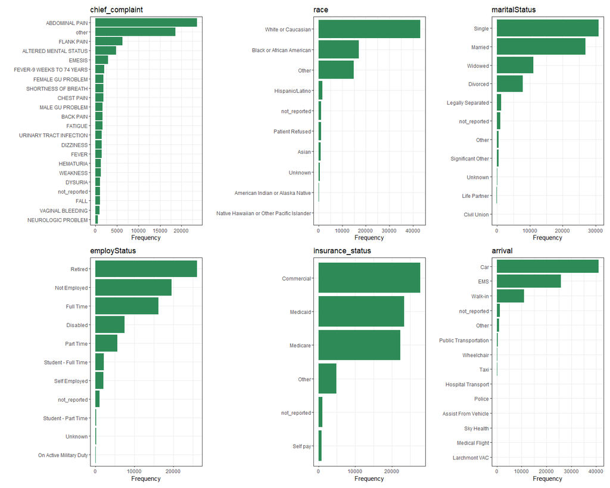

```r
get_p <- function(x){
  table(newdata[,x]) %>%
  as.data.frame() %>%
  ggplot(aes(x = reorder(Var1, Freq), y = Freq)) +
  geom_bar(stat = 'identity', fill = 'seagreen') +
  coord_flip() +
  labs(x = '', y = 'Frequency', title = x) +
  theme_bw()
}
p1 <- get_p('chief_complaint')
p2 <- get_p('race')
p3 <- get_p('maritalStatus')
p4 <- get_p('employStatus')
p5 <- get_p('insurance_status')
p6 <- get_p('arrival')

p1 + p2 + p3 + p4 + p5 + p6 + plot_layout(ncol = 3)
```

In addition, I checked the missing part of the data, and it can be found from the results that there is no missing part in the data.

```r
#find data having NA value
na_count = sapply(newdata, function(x) sum(is.na(x)))
which(na_count > 1)
```

```
#> named integer(0)
```

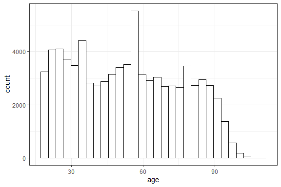

```r
ggplot(newdata, aes(x = age)) +
  geom_histogram(fill = 'white', col = 'black') +
  theme_bw()
```

```r
newdata%>%
  select(UTI_diag,gender)%>%
  tbl_summary(by = "UTI_diag")
```

| **Characteristic** | **No**, N = 63,221<sup>1</sup> | **Yes**, N = 17,166<sup>1</sup> |
| --- | --- | --- |
| gender |  |  |
| Female | 42,331 (67%) | 12,394 (72%) |
| Male | 20,013 (32%) | 4,571 (27%) |
| not_reported | 877 (1.4%) | 201 (1.2%) |

<sup>1</sup> n (%)

## Analysis

The dataset has been added to our `bis620.2022` package. Our target variable is binary, having “Yes” as UTI diagnosis and “No” as the opposite. We denoted them as 1 and 0 respectively for modeling. Data of variables that we are interested in are subsetted from the overall dataset.

One-hot encoding is processed that categorical data are converted into numerical data for use in machine learning models. It creates new binary columns, indicating the presence of each possible value from the corresponding original data. Data is also splitted into train and test data for evaluation

##### Logistic Regression Model

```r
mod_lr <- glm(UTI_diag ~ .,
               data = train, family = binomial)
pred_lr <- predict.glm(mod_lr, newdata = test, type = 'response')
get_m <- function(y, pred){
  pred <- as.numeric(pred >= 0.5)
  pred <- factor(pred, levels = c(0, 1))
  caret::confusionMatrix(y, pred)
}
get_m(test$UTI_diag, pred_lr)
```

```
#> Confusion Matrix and Statistics
#>
#>           Reference
#> Prediction     0     1
#>          0 12360   284
#>          1  2990   443
#>
#>                Accuracy : 0.7964
#>                  95% CI : (0.79, 0.8026)
#>     No Information Rate : 0.9548
#>     P-Value [Acc > NIR] : 1
#>
#>                   Kappa : 0.1495
#>
#>  Mcnemar's Test P-Value : <2e-16
#>
#>             Sensitivity : 0.8052
#>             Specificity : 0.6094
#>          Pos Pred Value : 0.9775
#>          Neg Pred Value : 0.1290
#>              Prevalence : 0.9548
#>          Detection Rate : 0.7688
#>    Detection Prevalence : 0.7865
#>       Balanced Accuracy : 0.7073
#>
#>        'Positive' Class : 0
#>
```

##### XGBoost

XGBoost is the abbreviation of eXtreme Gradient Boosting. It is a very powerful Boosting algorithm toolkit. Its excellent performance (effect and speed) has allowed it to dominate the data science competition solution list for a long time. Now many big manufacturers Machine learning solutions will still prefer this model. XGBoost is excellent in terms of parallel computing efficiency, missing value handling, overfitting control, and predictive generalization capabilities. Based on the model results, it can be found that the most important variable is `age`, followed by `chief_complaint` and `gender`.

```r
dat_m = model.matrix(~., data[,-1])
train_gb = xgb.DMatrix(data=dat_m[parts,], label=data$UTI_diag[parts])

dtrain <- xgb.DMatrix(data = data.matrix(train[,-1]),
                         label = as.integer(train[,1]) - 1)
dtest <- xgb.DMatrix(data = data.matrix(test[,-1]),
                         label = as.integer(test[,1]) - 1)
mod_xgb <- xgboost(data = dtrain,  max_depth = 10, eta = 0.5,
                 objective = "binary:logistic", nround = 25)
```

[figure not shown]

```r
importance_matrix = xgb.importance(colnames(dtrain), model = mod_xgb)
importance_matrix %>% as.data.frame() %>%
  arrange(desc(Gain)) %>%
  head(20) %>%
  ggplot(aes(x = reorder(Feature, Gain), y = Gain)) +
  geom_point() +
  geom_segment(aes(xend = reorder(Feature, Gain), yend = 0)) +
  theme_bw() +
  coord_flip() +
  labs(x = '', y = 'Importance')
```

```r
pred_xgb = predict(mod_xgb, dtest, outputmargin = F)
get_m(test$UTI_diag, pred_xgb)
```

```
#> Confusion Matrix and Statistics
#>
#>           Reference
#> Prediction     0     1
#>          0 12299   345
#>          1  3021   412
#>
#>                Accuracy : 0.7906
#>                  95% CI : (0.7843, 0.7969)
#>     No Information Rate : 0.9529
#>     P-Value [Acc > NIR] : 1
#>
#>                   Kappa : 0.1295
#>
#>  Mcnemar's Test P-Value : <2e-16
#>
#>             Sensitivity : 0.8028
#>             Specificity : 0.5443
#>          Pos Pred Value : 0.9727
#>          Neg Pred Value : 0.1200
#>              Prevalence : 0.9529
#>          Detection Rate : 0.7650
#>    Detection Prevalence : 0.7865
#>       Balanced Accuracy : 0.6735
#>
#>        'Positive' Class : 0
#>
```

```r
dat_pred <- data.frame(y = test$UTI_diag, `Logistic regression` = pred_lr,
                       `Xgboost` = pred_xgb)
roc_res <- roc(y ~ ., data = dat_pred)
```

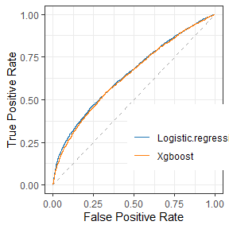

```r
ggroc(roc_res, legacy.axes = TRUE) +
  geom_segment(aes(x = 0, xend = 1, y = 0, yend = 1), color="darkgrey", linetype="dashed") +
  scale_color_d3() +
  labs(x = 'False Positive Rate', y = 'True Positive Rate', col = '') +
  theme_bw() +
  theme(legend.position = c(0.8, 0.3))
```

##### Check the influence of ‘Urinary_tract_infections’

```r
x <- as.data.frame(importance_matrix)
head(x,20)
```

```
#>                                   Feature       Gain       Cover   Frequency
#> 1                                     age 0.27788276 0.307279873 0.305906553
#> 2  chief_complaintURINARY.TRACT.INFECTION 0.06314025 0.016984579 0.007287687
#> 3                    chief_complaintFEVER 0.04950833 0.018797007 0.008639436
#> 4                  chief_complaintDYSURIA 0.03815625 0.021206304 0.005524537
#> 5                            genderFemale 0.03400780 0.006046900 0.047957684
#> 6        chief_complaintFEMALE.GU.PROBLEM 0.03322090 0.016832309 0.009403468
#> 7                              arrivalCar 0.02559201 0.006889358 0.031501616
#> 8              insurance_statusCommercial 0.02468827 0.009773262 0.034146341
#> 9                               raceOther 0.02053133 0.009421183 0.025330591
#> 10                    maritalStatusSingle 0.02002307 0.007265596 0.020922715
#> 11                 raceWhite.or.Caucasian 0.01987946 0.004977826 0.023273582
#> 12          raceBlack.or.African.American 0.01937854 0.008057757 0.028504261
#> 13                   maritalStatusMarried 0.01927963 0.009216346 0.023391125
#> 14                  maritalStatusDivorced 0.01664901 0.011490391 0.018983250
#> 15                             arrivalEMS 0.01605246 0.006351173 0.019453423
#> 16               employStatusNot.Employed 0.01560116 0.009304105 0.018042903
#> 17               insurance_statusMedicare 0.01527781 0.010763831 0.014516603
#> 18                  employStatusFull.Time 0.01499219 0.007040160 0.016632383
#> 19                         arrivalWalk.in 0.01467834 0.007186091 0.017866588
#> 20               insurance_statusMedicaid 0.01402563 0.009989599 0.017396415
```

```r
p2 = predict(xgb_model, newdata = X_test)
caret::MAE(y_test, p2) #mae
caret::RMSE(y_test, p2) #rmse
auc(test$UTI_diag, p2) #auc
```

```
#> Area under the curve: 0.6393
```

```r
#create new data containing 'Urinary_tract_infections'
data_uti = newdata[ , c('UTI_diag','Urinary_tract_infections','chief_complaint','age','gender','race','employStatus','maritalStatus', 'insurance_status','arrival')]
data_uti$Urinary_tract_infections[data_uti$Urinary_tract_infections == "Yes"]<-1
data_uti$Urinary_tract_infections[data_uti$Urinary_tract_infections == "No"]<-0
data_uti$Urinary_tract_infections <- as.numeric(data_uti$Urinary_tract_infections)
data_uti$UTI_diag[data_uti$UTI_diag == "Yes"]<-1
data_uti$UTI_diag[data_uti$UTI_diag == "No"]<-0
data_uti$UTI_diag <- as.numeric(data_uti$UTI_diag)
```

```r
#One-hot encoder
dummy <- dummyVars(" ~ .", data=data_uti)
data_uti <- data.frame(predict(dummy, newdata = data_uti))
```

```r
#Split into 'Urinary_tract_infections = 1' and 'Urinary_tract_infections = 0'
data_uti1 = data_uti[which(data_uti$Urinary_tract_infections == 1),]
data_uti1 = data_uti1[,!(colnames(data_uti1) == "Urinary_tract_infections")]
data_uti0 = data_uti[which(data_uti$Urinary_tract_infections == 0),]
data_uti0 = data_uti0[,!(colnames(data_uti0) == "Urinary_tract_infections")]
```

```r
#### train,test data split
parts1 = createDataPartition(data_uti1$UTI_diag, p = 0.8, list = F)
train1 = data_uti1[parts1, ]
test1 = data_uti1[-parts1, ]
```

```r
#Show the feature importance
x <- as.data.frame(importance_matrix)
head(x,20)
```

```
#>                                   Feature       Gain       Cover   Frequency
#> 1                                     age 0.32915560 0.343045047 0.342161124
#> 2  chief_complaintURINARY.TRACT.INFECTION 0.03753428 0.018586392 0.012938441
#> 3           raceBlack.or.African.American 0.03081995 0.012495636 0.027797433
#> 4                            genderFemale 0.02907302 0.008581898 0.035378550
#> 5                    maritalStatusMarried 0.02888813 0.009209769 0.027190943
#> 6                              arrivalCar 0.02842558 0.016379618 0.036591529
#> 7              insurance_statusCommercial 0.02824878 0.007612786 0.028707167
#> 8           chief_complaintABDOMINAL.PAIN 0.02749062 0.011877935 0.038107753
#> 9                  chief_complaintDYSURIA 0.02331033 0.017920857 0.008389771
#> 10                              raceOther 0.02298135 0.011028220 0.023855251
#> 11                   chief_complaintother 0.02103258 0.009482084 0.026079046
#> 12                             arrivalEMS 0.01987632 0.009157038 0.022035783
#> 13   chief_complaintALTERED.MENTAL.STATUS 0.01959925 0.013024824 0.018599009
#> 14                    maritalStatusSingle 0.01931931 0.010171725 0.016880623
#> 15                 raceWhite.or.Caucasian 0.01928093 0.005825597 0.015768725
#> 16               employStatusNot.Employed 0.01730197 0.014613144 0.015566562
#> 17                   maritalStatusWidowed 0.01666556 0.013710322 0.015768725
#> 18               insurance_statusMedicare 0.01622365 0.008761559 0.010613565
#> 19                   employStatusDisabled 0.01547276 0.008798094 0.013646012
#> 20                  maritalStatusDivorced 0.01510754 0.013221811 0.014757910
```

```r
#Evaluation
p2 = predict(xgb_model, newdata = X_test)
caret::MAE(y_test, p2) #mae
caret::RMSE(y_test, p2) #rmse
auc(test$UTI_diag, p2) #auc
```

```
#> Area under the curve: 0.592
```

```r
#### train,test data split
parts0 = createDataPartition(data_uti0$UTI_diag, p = 0.8, list = F)
train0 = data_uti0[parts0, ]
test0 = data_uti0[-parts0, ]
```

```r
#Show the feature importance
x <- as.data.frame(importance_matrix)
head(x,20)
```

```
#>                                   Feature       Gain       Cover   Frequency
#> 1                                     age 0.27393515 0.308819535 0.297398641
#> 2  chief_complaintURINARY.TRACT.INFECTION 0.05854250 0.017441557 0.007323647
#> 3                    chief_complaintFEVER 0.04699266 0.022609653 0.007030701
#> 4                  chief_complaintDYSURIA 0.03573592 0.016847729 0.007440825
#> 5                            genderFemale 0.03409516 0.009580311 0.046871338
#> 6        chief_complaintFEMALE.GU.PROBLEM 0.02652392 0.013490955 0.008905554
#> 7              insurance_statusCommercial 0.02569156 0.009110777 0.035094914
#> 8           raceBlack.or.African.American 0.02381232 0.007650938 0.029704711
#> 9                              arrivalCar 0.02319509 0.010048262 0.029001640
#> 10                              raceOther 0.02196993 0.007291794 0.027243965
#> 11                 raceWhite.or.Caucasian 0.02112416 0.006964262 0.020330443
#> 12                   maritalStatusMarried 0.02053312 0.004561878 0.024958988
#> 13                  maritalStatusDivorced 0.01885973 0.008509596 0.019100070
#> 14               chief_complaintHEMATURIA 0.01691997 0.017787106 0.009022733
#> 15                  employStatusFull.Time 0.01676375 0.007974261 0.020447621
#> 16                    maritalStatusSingle 0.01576806 0.007821714 0.018045465
#> 17               insurance_statusMedicaid 0.01550539 0.006008288 0.018279822
#> 18                         arrivalWalk.in 0.01539293 0.010997308 0.016756503
#> 19                             arrivalEMS 0.01520429 0.007793106 0.016990860
#> 20               insurance_statusMedicare 0.01503405 0.010545104 0.013299742
```

```r
#Evaluation
p2 = predict(xgb_model, newdata = X_test)
caret::MAE(y_test, p2) #mae
caret::RMSE(y_test, p2) #rmse
auc(test$UTI_diag, p2) #auc
```

```
#> Area under the curve: 0.8023
```

#### Referenes

https://www.womenshealth.gov/a-z-topics/urinary-tract-infections https://myhealth.alberta.ca/Health/aftercareinformation/pages/conditions.aspx?hwid=av2874 https://journals.plos.org/plosone/article?id=10.1371/journal.pone.0194085 https://www.ncbi.nlm.nih.gov/pmc/articles/PMC8231389/ https://www.ncbi.nlm.nih.gov/pmc/articles/PMC8077804/